# Processing LLMC outputs

# 1 Goal

The goal of this notebook is to read in the 66 csv files of results and the seven csv files of true answers and then process them for subsequent analysis. We will end up with one giant data frame (which we write to csv) that will have the following columns:

`llm`, `qset`, `question_id`, `stated_confidence`, `chosen_token_confidence`, `max_token_confidence`, `correct`.

We define these columns in terms of the following notation:

- $C_i^\text{stated}(k)$ is the stated confidence for choice $k$ in question $i$
- $C_i^\text{token}(k)$ is the token confidence for choice $k$ in question $i$
- $y_i$ is the correct answer
- $\hat y_i$ is an LLM’s chosen answer

The column `stated_confidence` is $C_i^\text{stated}(\hat y_i)$, i.e. the stated confidence associated with the LLM’s chosen answer.

The column `chosen_token_confidence` is $C_i^\text{token}(\hat y_i)$, i.e. the token-based confidence associated with the LLM’s chosen answer.

The column `max_token_confidence` is $\max_kC_i^\text{token}(k)$, i.e. the token-based confidence associated with what the LLM would choose if temperature were 0.

# 2 Load the data

```r
library(tidyverse)
```

```r
path <- "../"
csvs <- fs::dir_ls(file.path(path, "Parsed Results"),recurse = TRUE, glob="*csv")
```

There are 66 files of LLM results in total. Let’s extract the LLM and Qset for each file:

```r
stems <- csvs %>% fs::path_file() %>% str_remove(".csv")
llm <- stems %>% str_extract("[^_]+$")
qset <- stems %>% str_remove(paste0("_", llm))
```

```r
all <- tibble(llm = llm, qset = qset, csv = csvs)
all <- all %>% mutate(dat = map(csv, read_csv, show_col_types=FALSE))
```

Let’s also get the truth

```r
truth_csvs <- fs::dir_ls(file.path(path, "Formatted Benchmarks"))
qset_truth_name <- fs::path_file(truth_csvs) %>% str_remove(".csv") %>% str_remove("_formatted")
truth <- map(truth_csvs, read_csv, show_col_types = FALSE)
names(truth) <- qset_truth_name
```

There’s a problem with the first csv (a lot of empty rows at end).

```r
# remove last row:
truth[[1]] <- truth[[1]] %>% slice(1:119)
```

# 3 Standardizing format

We will work our way through the 7 question sets, which have different formats. Also, the GPT-4 and Llama models need to be treated differently because they also output token probabilities.

## 3.1 Boolq

### 3.1.1 GPT-4 and Llama models

Notice that after filtering based on coerce, we get all expected answers:

```r
all %>%
  filter(qset == "boolq_valid", str_detect(llm, "Llama|gpt")) %>%
  unnest(cols = dat) %>%
  filter(coerce) %>%
  count(Answer, sort=TRUE)
```

```
## # A tibble: 2 × 2
##   Answer     n
##   <chr>  <int>
## 1 True    4880
## 2 False   4808
```

```r
eval1 <- all %>%
  filter(qset == "boolq_valid", str_detect(llm, "Llama|gpt")) %>%
  unnest(cols = dat) %>%
  filter(coerce, Answer %in% c("True", "False")) %>%
  select(llm, qset, `Question ID`, Answer, Confidence, True_prob, False_prob) %>%
  transmute(
    llm,
    qset,
    question_id = `Question ID`,
    stated_confidence = Confidence,
    chosen_token_confidence = if_else(Answer == "True", True_prob, False_prob) / (True_prob + False_prob),
    max_token_confidence = pmax(True_prob, False_prob),
    answer = Answer == "True",
    stated_gini = 1 - Confidence^2 - (1 - Confidence)^2,
    token_gini = 1 - True_prob^2 - False_prob^2
    ) %>%
  left_join(
    truth$boolq_valid %>% select(question_id = `Question ID`, `Correct Answer`),
    by = "question_id"
    ) %>%
  mutate(
    correct = answer == `Correct Answer`
  ) %>%
  select(-answer, -`Correct Answer`)
```

### 3.1.2 Models without token probabilities

Before we can `unnest`, we need all the data frames to have the same format of columns.

```r
all %>%
  filter(qset == "boolq_valid", !str_detect(llm, "Llama|gpt")) %>%
  pull(dat) %>%
  map_dfr(~ map_chr(.x, class))
```

```
## # A tibble: 8 × 6
##   Reasoning Answer    Confidence coerce  content   `Question ID`
##   <chr>     <chr>     <chr>      <chr>   <chr>     <chr>
## 1 character logical   numeric    logical character numeric
## 2 character character numeric    logical character numeric
## 3 character character numeric    logical character numeric
## 4 character character numeric    logical character numeric
## 5 character character numeric    logical character numeric
## 6 character character numeric    logical character numeric
## 7 character character numeric    logical character numeric
## 8 character character numeric    logical character numeric
```

We see that the `Answer` column for the first one (`claude-3-7-sonnet-20250219`) needs to be fixed.

```r
row <- which(all$qset == "boolq_valid" & all$llm == "claude-3-7-sonnet-20250219")
all[row,"dat"][[1]][[1]]$Answer <- ifelse(all[row,"dat"][[1]][[1]]$Answer, "True", "False")
```

```r
all %>%
  filter(qset == "boolq_valid", !str_detect(llm, "Llama|gpt")) %>%
  unnest(cols = dat) %>%
  filter(coerce) %>%
  count(Answer, sort=TRUE)
```

```
## # A tibble: 2 × 2
##   Answer     n
##   <chr>  <int>
## 1 True   13347
## 2 False  11847
```

```r
eval2 <- all %>%
  filter(qset == "boolq_valid", !str_detect(llm, "Llama|gpt")) %>%
  unnest(cols = dat) %>%
  filter(coerce) %>%
  select(llm, qset, `Question ID`, Answer, Confidence) %>%
  transmute(
    llm,
    qset,
    question_id = `Question ID`,
    stated_confidence = Confidence,
    answer = Answer == "True",
    stated_gini = 1 - Confidence^2 - (1 - Confidence)^2
    ) %>%
  left_join(
    truth$boolq_valid %>% select(question_id = `Question ID`, `Correct Answer`),
    by = "question_id"
    ) %>%
  mutate(
    correct = answer == `Correct Answer`
  ) %>%
  select(-answer, -`Correct Answer`)
```

## 3.2 LSAT

### 3.2.1 GPT-4 and Llama models

Notice that we get all expected answers:

```r
all %>%
  filter(qset == "lsat_ar_test", str_detect(llm, "Llama|gpt")) %>%
  unnest(cols = dat) %>%
  filter(coerce) %>%
  pull(Answer) %>%
  unique() %>%
  {. %in% c("A", "B", "C", "D", "E")} %>%
  all() %>%
  stopifnot()
```

Observe that the five probabilities don’t always sum to 1 (but do so most of the time):

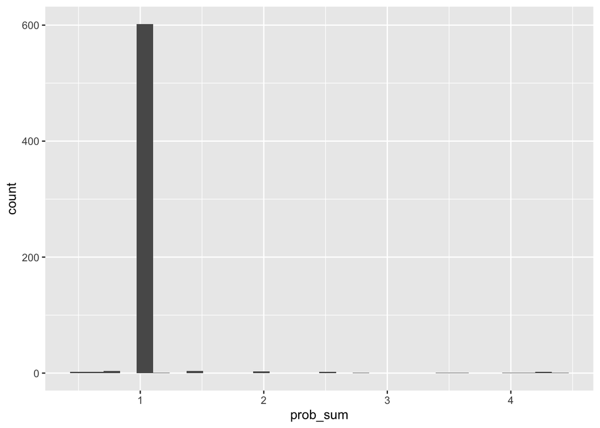

```r
all %>%
  filter(qset == "lsat_ar_test", str_detect(llm, "Llama|gpt")) %>%
  unnest(cols = dat) %>%
  filter(coerce) %>%
  mutate(prob_sum = A+B+C+D+E) %>%
  ggplot(aes(x=prob_sum)) + geom_histogram()
```

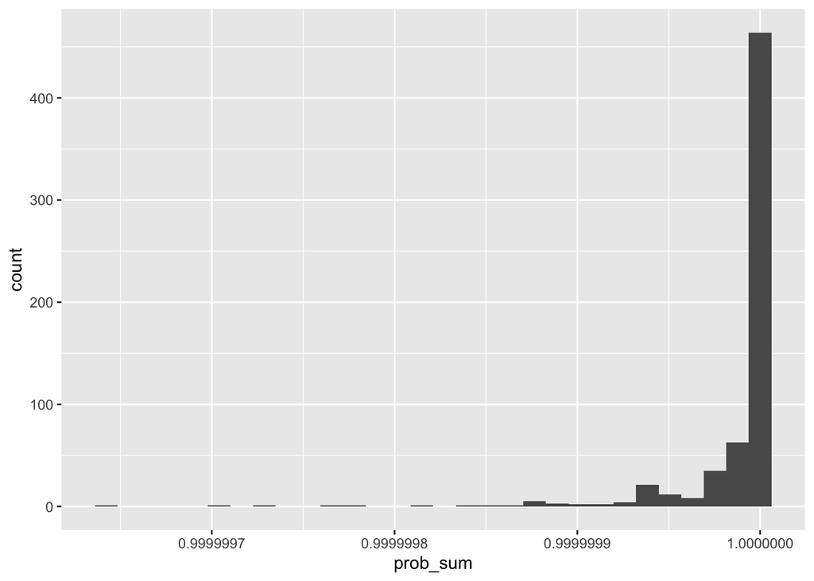

```r
all %>%
  filter(qset == "lsat_ar_test", str_detect(llm, "Llama|gpt")) %>%
  unnest(cols = dat) %>%
  filter(coerce) %>%
  mutate(prob_sum = A_prob+B_prob+C_prob+D_prob+E_prob) %>%
  ggplot(aes(x=prob_sum)) + geom_histogram()
```

The prereg says we will normalize the confidences, so let’s do that:

```r
eval3 <- all %>%
  filter(qset == "lsat_ar_test", str_detect(llm, "Llama|gpt")) %>%
  unnest(cols = dat) %>%
  filter(coerce) %>%
  transmute(
    llm,
    qset,
    question_id = `Question ID`,
    Answer,
    prob_sum = A+B+C+D+E,
    stated_confidence = case_when(
      Answer == "A" ~ A,
      Answer == "B" ~ B,
      Answer == "C" ~ C,
      Answer == "D" ~ D,
      Answer == "E" ~ E,
    ) / if_else(prob_sum == 0, 1, prob_sum), # we take 0/0 to be 0.
    prob_token_sum = A_prob+B_prob+C_prob+D_prob+E_prob,
    chosen_token_confidence = case_when(
      Answer == "A" ~ A_prob,
      Answer == "B" ~ B_prob,
      Answer == "C" ~ C_prob,
      Answer == "D" ~ D_prob,
      Answer == "E" ~ E_prob,
    ) / if_else(prob_token_sum == 0, 1, prob_token_sum),
    max_token_confidence = pmax(A_prob, B_prob, C_prob, D_prob, E_prob) / if_else(prob_token_sum == 0, 1, prob_token_sum),
    stated_gini = 1 - (A^2 + B^2 + C^2 + D^2 + E^2) / if_else(prob_sum == 0, 1, prob_sum)^2,
    token_gini = 1 - (A_prob^2 + B_prob^2 + C_prob^2 + D_prob^2 + E_prob^2) / if_else(prob_token_sum == 0, 1, prob_token_sum)^2,
    ) %>%
  left_join(
    truth$lsat_ar_test %>% select(question_id = `Question ID`, `Correct Answer Letter`),
    by = "question_id"
    ) %>%
  mutate(
    correct = Answer == `Correct Answer Letter`
  ) %>%
  select(-Answer, -`Correct Answer Letter`, -prob_sum, -prob_token_sum)
```

### 3.2.2 Models without token probabilities

```r
all %>%
  filter(qset == "lsat_ar_test", !str_detect(llm, "Llama|gpt")) %>%
  unnest(cols = dat) %>%
  filter(coerce) %>%
  count(Answer)
```

```
## # A tibble: 5 × 2
##   Answer     n
##   <chr>  <int>
## 1 A        309
## 2 B        297
## 3 C        376
## 4 D        372
## 5 E        306
```

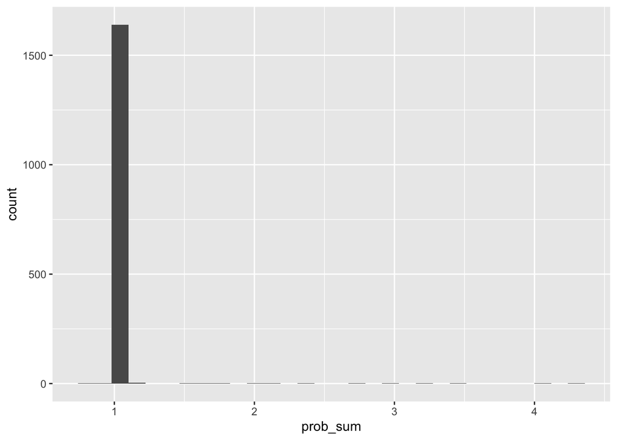

```r
all %>%
  filter(qset == "lsat_ar_test", !str_detect(llm, "Llama|gpt")) %>%
  unnest(cols = dat) %>%
  filter(coerce) %>%
  mutate(prob_sum = A+B+C+D+E) %>%
  ggplot(aes(x=prob_sum)) + geom_histogram()
```

```r
eval4 <- all %>%
  filter(qset == "lsat_ar_test", !str_detect(llm, "Llama|gpt")) %>%
  unnest(cols = dat) %>%
  filter(coerce, Answer %in% LETTERS[1:5]) %>%
  transmute(
    llm,
    qset,
    question_id = `Question ID`,
    Answer,
    prob_sum = A+B+C+D+E,
    stated_confidence = case_when(
      Answer == "A" ~ A,
      Answer == "B" ~ B,
      Answer == "C" ~ C,
      Answer == "D" ~ D,
      Answer == "E" ~ E,
    ) / if_else(prob_sum == 0, 1, prob_sum), # we take 0/0 to be 0.
    stated_gini = 1 - (A^2 + B^2 + C^2 + D^2 + E^2) / if_else(prob_sum == 0, 1, prob_sum)^2
    ) %>%
  left_join(
    truth$lsat_ar_test %>% select(question_id = `Question ID`, `Correct Answer Letter`),
    by = "question_id"
    ) %>%
  mutate(
    correct = Answer == `Correct Answer Letter`
  ) %>%
  select(-Answer, -`Correct Answer Letter`, -prob_sum)
```

## 3.3 SAT

### 3.3.1 GPT-4 and Llama models

```r
all %>%
  filter(qset == "sat_en", str_detect(llm, "Llama|gpt")) %>%
  unnest(cols = dat) %>%
  filter(coerce) %>%
  count(Answer)
```

```
## # A tibble: 4 × 2
##   Answer     n
##   <chr>  <int>
## 1 A        194
## 2 B        162
## 3 C        114
## 4 D        140
```

Let’s look at the sums of the probabilities.

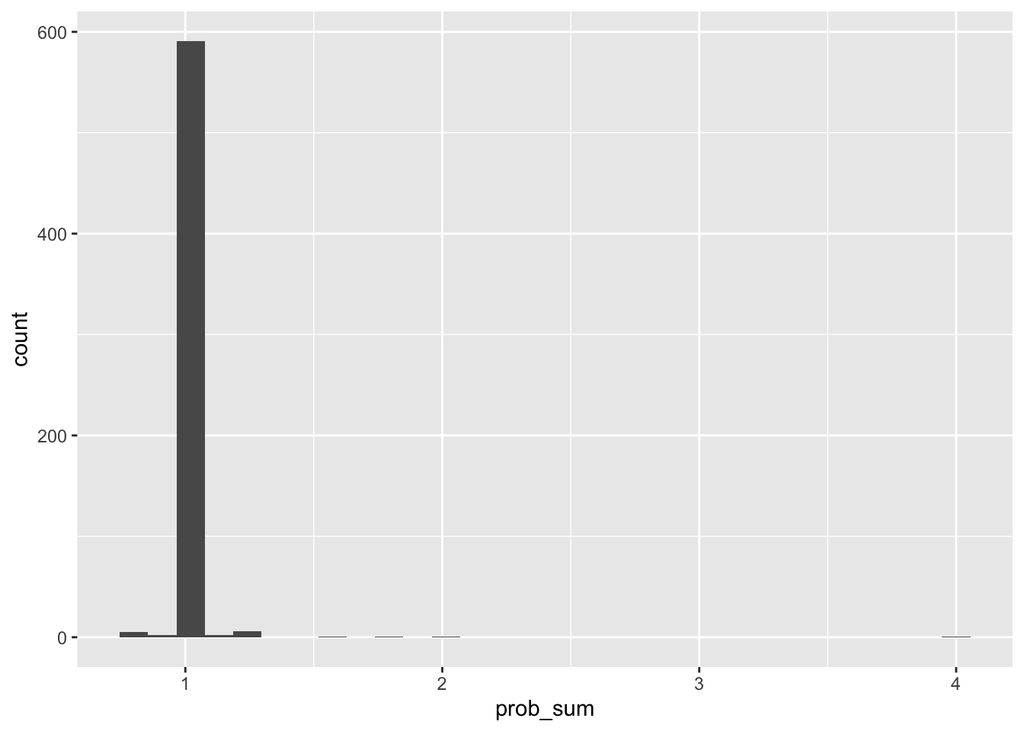

```r
all %>%
  filter(qset == "sat_en", str_detect(llm, "Llama|gpt")) %>%
  unnest(cols = dat) %>%
  filter(coerce) %>%
  mutate(prob_sum = A+B+C+D) %>%
  ggplot(aes(x=prob_sum)) + geom_histogram()
```

```r
all %>%
  filter(qset == "sat_en", str_detect(llm, "Llama|gpt")) %>%
  unnest(cols = dat) %>%
  filter(coerce) %>%
  mutate(prob_sum = A+B+C+D) %>%
  filter(prob_sum == 0)
```

```
## # A tibble: 0 × 17
## # ℹ 17 variables: llm <chr>, qset <chr>, csv <fs::path>, Reasoning <chr>,
## #   Answer <chr>, A <dbl>, B <dbl>, C <dbl>, D <dbl>, coerce <lgl>,
## #   content <chr>, Question ID <dbl>, A_prob <dbl>, B_prob <dbl>, C_prob <dbl>,
## #   D_prob <dbl>, prob_sum <dbl>
```

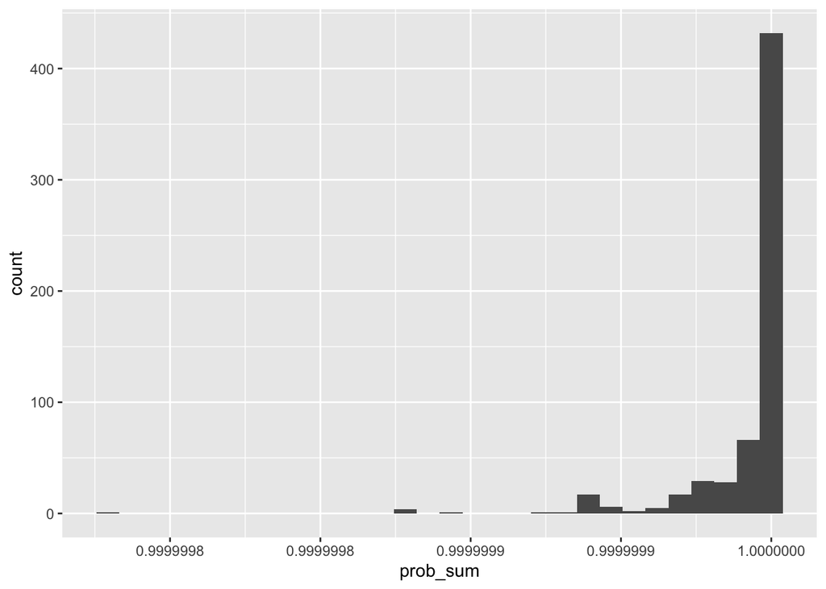

```r
all %>%
  filter(qset == "sat_en", str_detect(llm, "Llama|gpt")) %>%
  unnest(cols = dat) %>%
  filter(coerce) %>%
  mutate(prob_sum = A_prob+B_prob+C_prob+D_prob) %>%
  ggplot(aes(x=prob_sum)) + geom_histogram()
```

```r
eval5 <- all %>%
  filter(qset == "sat_en", str_detect(llm, "Llama|gpt")) %>%
  unnest(cols = dat) %>%
  filter(coerce, Answer %in% LETTERS[1:4]) %>%
  transmute(
    llm,
    qset,
    question_id = `Question ID`,
    Answer,
    prob_sum = A+B+C+D,
    stated_confidence = case_when(
      Answer == "A" ~ A,
      Answer == "B" ~ B,
      Answer == "C" ~ C,
      Answer == "D" ~ D
    ) / if_else(prob_sum == 0, 1, prob_sum), # we take 0/0 to be 0.
    prob_token_sum = A_prob+B_prob+C_prob+D_prob,
    chosen_token_confidence = case_when(
      Answer == "A" ~ A_prob,
      Answer == "B" ~ B_prob,
      Answer == "C" ~ C_prob,
      Answer == "D" ~ D_prob
    ) / if_else(prob_token_sum == 0, 1, prob_token_sum),
    max_token_confidence = pmax(A_prob, B_prob, C_prob, D_prob) / if_else(prob_token_sum == 0, 1, prob_token_sum),
    stated_gini = 1 - (A^2 + B^2 + C^2 + D^2) / if_else(prob_sum == 0, 1, prob_sum)^2,
    token_gini = 1 - (A_prob^2 + B_prob^2 + C_prob^2 + D_prob^2) / if_else(prob_token_sum == 0, 1, prob_token_sum)^2
    ) %>%
  left_join(
    truth$sat_en %>% select(question_id = `Question ID`, `Correct Answer Letter`),
    by = "question_id"
    ) %>%
  mutate(
    correct = Answer == `Correct Answer Letter`
  ) %>%
  select(-Answer, -`Correct Answer Letter`, -prob_sum, -prob_token_sum)
```

### 3.3.2 Models without token probabilities

Notice that we get a non-compliant answer (“E”).

```r
all %>%
  filter(qset == "sat_en", !str_detect(llm, "Llama|gpt")) %>%
  unnest(cols = dat) %>%
  filter(coerce) %>%
  count(Answer)
```

```
## # A tibble: 5 × 2
##   Answer     n
##   <chr>  <int>
## 1 A        508
## 2 B        423
## 3 C        291
## 4 D        394
## 5 E          1
```

Let’s look at the sums of the probabilities.

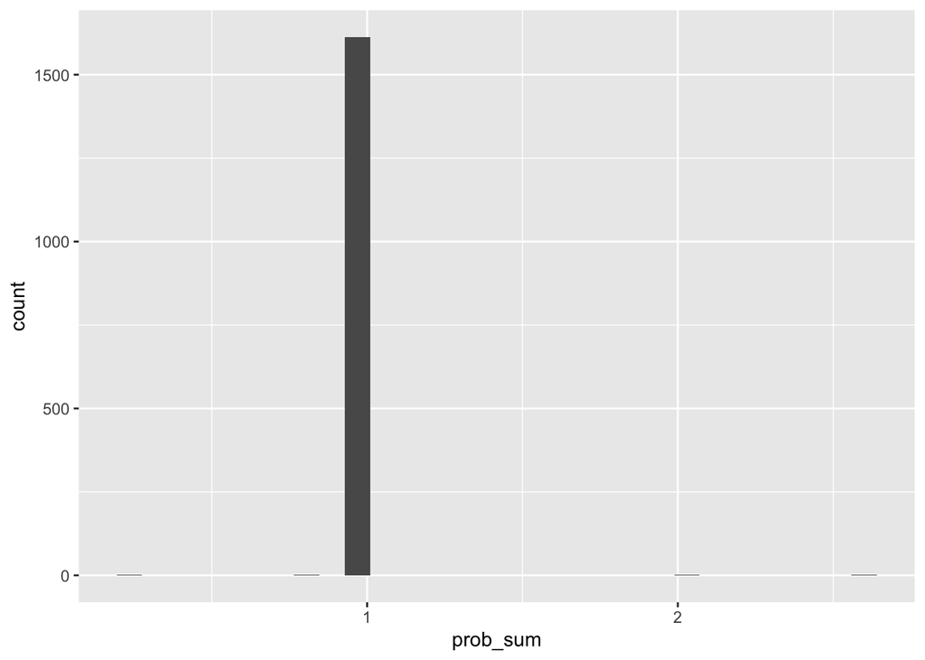

```r
all %>%
  filter(qset == "sat_en", !str_detect(llm, "Llama|gpt")) %>%
  unnest(cols = dat) %>%
  filter(coerce) %>%
  mutate(prob_sum = A+B+C+D) %>%
  ggplot(aes(x=prob_sum)) + geom_histogram()
```

```r
eval6 <- all %>%
  filter(qset == "sat_en", !str_detect(llm, "Llama|gpt")) %>%
  unnest(cols = dat) %>%
  filter(coerce, Answer %in% LETTERS[1:4]) %>%
  transmute(
    llm,
    qset,
    question_id = `Question ID`,
    Answer,
    prob_sum = A+B+C+D,
    stated_confidence = case_when(
      Answer == "A" ~ A,
      Answer == "B" ~ B,
      Answer == "C" ~ C,
      Answer == "D" ~ D
    ) / if_else(prob_sum == 0, 1, prob_sum), # we take 0/0 to be 0.
    stated_gini = 1 - (A^2 + B^2 + C^2 + D^2) / if_else(prob_sum == 0, 1, prob_sum)^2
    ) %>%
  left_join(
    truth$sat_en %>% select(question_id = `Question ID`, `Correct Answer Letter`),
    by = "question_id"
    ) %>%
  mutate(
    correct = Answer == `Correct Answer Letter`
  ) %>%
  select(-Answer, -`Correct Answer Letter`, -prob_sum)
```

## 3.4 Sciq

### 3.4.1 GPT-4 and Llama models

All compliant answers:

```r
all %>%
  filter(qset == "sciq_test", str_detect(llm, "Llama|gpt")) %>%
  unnest(cols = dat) %>%
  filter(coerce) %>%
  count(Answer)
```

```
## # A tibble: 4 × 2
##   Answer     n
##   <chr>  <int>
## 1 A        796
## 2 B        688
## 3 C        696
## 4 D        817
```

Let’s look at the sums of the probabilities.

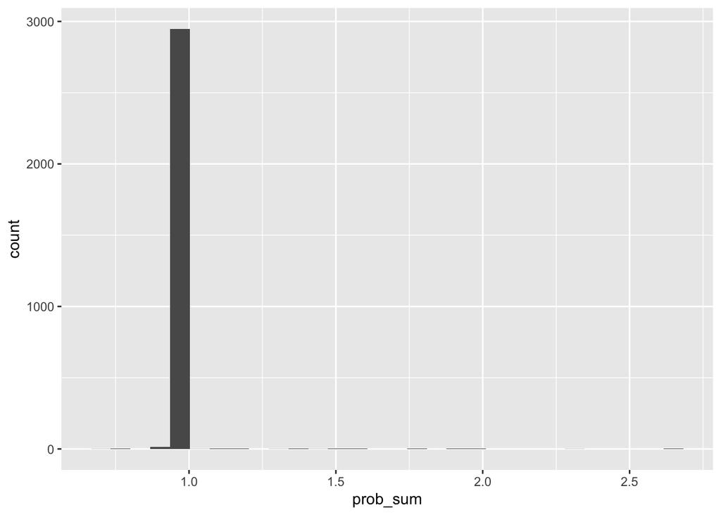

```r
all %>%
  filter(qset == "sciq_test", str_detect(llm, "Llama|gpt")) %>%
  unnest(cols = dat) %>%
  filter(coerce) %>%
  mutate(prob_sum = A+B+C+D) %>%
  ggplot(aes(x=prob_sum)) + geom_histogram()
```

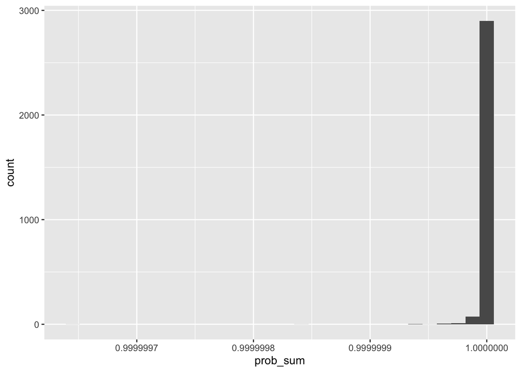

```r
all %>%
  filter(qset == "sciq_test", str_detect(llm, "Llama|gpt")) %>%
  unnest(cols = dat) %>%
  filter(coerce) %>%
  mutate(prob_sum = A_prob+B_prob+C_prob+D_prob) %>%
  ggplot(aes(x=prob_sum)) + geom_histogram()
```

```r
eval7 <- all %>%
  filter(qset == "sciq_test", str_detect(llm, "Llama|gpt")) %>%
  unnest(cols = dat) %>%
  filter(coerce, Answer %in% LETTERS[1:4]) %>%
  transmute(
    llm,
    qset,
    question_id = `Question ID`,
    Answer,
    prob_sum = A+B+C+D,
    stated_confidence = case_when(
      Answer == "A" ~ A,
      Answer == "B" ~ B,
      Answer == "C" ~ C,
      Answer == "D" ~ D
    ) / if_else(prob_sum == 0, 1, prob_sum), # we take 0/0 to be 0.
    prob_token_sum = A_prob+B_prob+C_prob+D_prob,
    chosen_token_confidence = case_when(
      Answer == "A" ~ A_prob,
      Answer == "B" ~ B_prob,
      Answer == "C" ~ C_prob,
      Answer == "D" ~ D_prob
    ) / if_else(prob_token_sum == 0, 1, prob_token_sum),
    max_token_confidence = pmax(A_prob, B_prob, C_prob, D_prob) / if_else(prob_token_sum == 0, 1, prob_token_sum),
    stated_gini = 1 - (A^2 + B^2 + C^2 + D^2) / if_else(prob_sum == 0, 1, prob_sum)^2,
    token_gini = 1 - (A_prob^2 + B_prob^2 + C_prob^2 + D_prob^2) / if_else(prob_token_sum == 0, 1, prob_token_sum)^2
    ) %>%
  left_join(
    truth$sciq_test %>% select(question_id = `Question ID`, `Correct Answer Letter`),
    by = "question_id"
    ) %>%
  mutate(
    correct = Answer == `Correct Answer Letter`
  ) %>%
  select(-Answer, -`Correct Answer Letter`, -prob_sum, -prob_token_sum)
```

### 3.4.2 Models without token probabilities

All compliant answers:

```r
all %>%
  filter(qset == "sciq_test", !str_detect(llm, "Llama|gpt")) %>%
  unnest(cols = dat) %>%
  filter(coerce) %>%
  count(Answer)
```

```
## # A tibble: 4 × 2
##   Answer     n
##   <chr>  <int>
## 1 A       2106
## 2 B       1836
## 3 C       1852
## 4 D       2204
```

Let’s look at the sums of the probabilities.

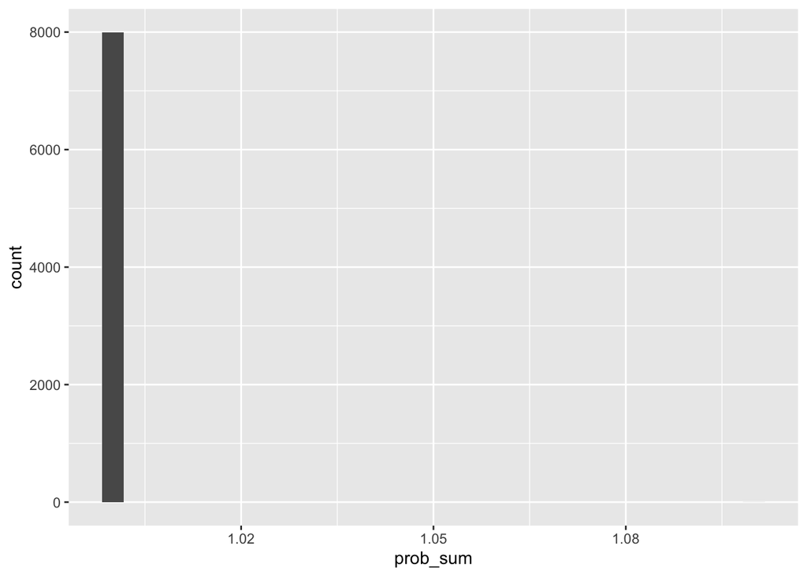

```r
all %>%
  filter(qset == "sciq_test", !str_detect(llm, "Llama|gpt")) %>%
  unnest(cols = dat) %>%
  filter(coerce) %>%
  mutate(prob_sum = A+B+C+D) %>%
  ggplot(aes(x=prob_sum)) + geom_histogram()
```

```r
eval8 <- all %>%
  filter(qset == "sciq_test", !str_detect(llm, "Llama|gpt")) %>%
  unnest(cols = dat) %>%
  filter(coerce, Answer %in% LETTERS[1:4]) %>%
  transmute(
    llm,
    qset,
    question_id = `Question ID`,
    Answer,
    prob_sum = A+B+C+D,
    stated_confidence = case_when(
      Answer == "A" ~ A,
      Answer == "B" ~ B,
      Answer == "C" ~ C,
      Answer == "D" ~ D
    ) / if_else(prob_sum == 0, 1, prob_sum), # we take 0/0 to be 0.
    stated_gini = 1 - (A^2 + B^2 + C^2 + D^2) / if_else(prob_sum == 0, 1, prob_sum)^2
    ) %>%
  left_join(
    truth$sciq_test %>% select(question_id = `Question ID`, `Correct Answer Letter`),
    by = "question_id"
    ) %>%
  mutate(
    correct = Answer == `Correct Answer Letter`
  ) %>%
  select(-Answer, -`Correct Answer Letter`, -prob_sum)
```

## 3.5 halu_eval

For this Qset, we don’t need to distinguish between models with/without token probabilities, because we do not get token probabilities. Also, the format is pretty different, in that we don’t have the models choose an answer, rather we seed it with a correct and a hallucinated answer, and ask for its (stated) confidence in each case.

```r
halu <- all %>%
  filter(qset == "halu_eval_qa") %>%
  unnest(cols = dat) %>%
  filter(coerce)
```

```r
eval9 <- halu %>%
  transmute(
    qset,
    llm,
    question_id = `Question ID`,
    stated_confidence = Confidence,
    correct = str_detect(question_id, "r")
    )
```

## 3.6 life_eval

For this Qset, we don’t need to distinguish between models with/without token probabilities, because we do not get token probabilities. Also, the setup here is different from the previous Qsets

Before we can `unnest`, we need all the data frames to have the same format of columns.

```r
all %>%
  filter(qset == "life_eval") %>%
  pull(dat) %>%
  map_dfr(~ map_chr(.x, class))
```

```
## # A tibble: 11 × 7
##    Reasoning Answer  Confidence coerce  content   `Question ID` Answer_prob
##    <chr>     <chr>   <chr>      <chr>   <chr>     <chr>         <chr>
##  1 character numeric numeric    logical character numeric       <NA>
##  2 character numeric numeric    logical character numeric       <NA>
##  3 character numeric numeric    logical character numeric       <NA>
##  4 character numeric numeric    logical character numeric       <NA>
##  5 character numeric numeric    logical character numeric       <NA>
##  6 character numeric numeric    logical character numeric       numeric
##  7 character numeric numeric    logical character numeric       <NA>
##  8 character numeric numeric    logical character numeric       <NA>
##  9 character numeric character  logical character numeric       <NA>
## 10 character numeric numeric    logical character numeric       numeric
## 11 character numeric numeric    logical character numeric       numeric
```

Let’s fix the one that has a `Confidence` column that is `"character"` rather than `"numeric"`.

```r
row <- which(all$llm == "gemini-2.5-pro" & all$qset == "life_eval")
all[row,"dat"][[1]][[1]]$Confidence <- as.numeric(all[row,"dat"][[1]][[1]]$Confidence)
```

The reason that it was in character was that in one case it responded in a sentence rather than a number, and that’s now been coerced to NA in the above code. We’ll be sure to remove that one below.

Let’s look at the answers given:

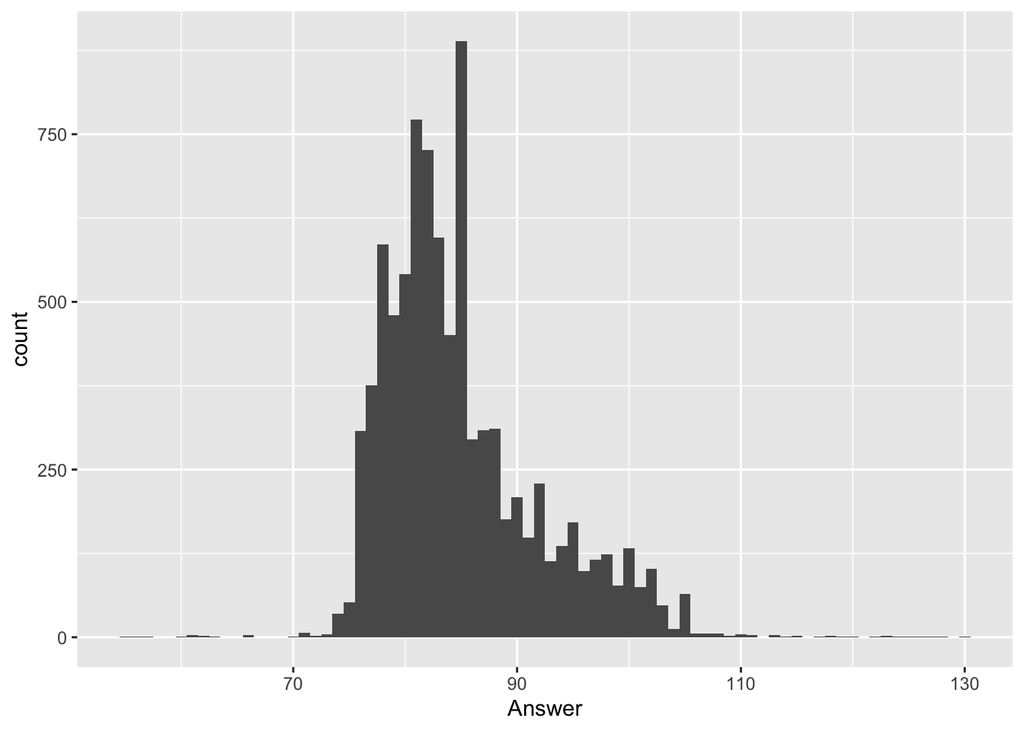

```r
all %>%
  filter(qset == "life_eval") %>%
  unnest(cols = dat) %>%
  filter(coerce, !is.na(Confidence)) %>%
  ggplot(aes(x=Answer)) +
  geom_histogram(binwidth=1)
```

```r
eval10 <- all %>%
  filter(qset == "life_eval") %>%
  unnest(cols = dat) %>%
  filter(coerce, !is.na(Confidence)) %>%
  left_join(truth$life_eval, by = "Question ID") %>%
  transmute(
    qset,
    llm,
    question_id = as.character(`Question ID`),
    answer = Answer,
    min_age = as.numeric(str_extract(`Question Prompt`, "\\d+")),
    width = as.numeric(str_extract(`Confidence Prompt`, "\\d+")),
    stated_confidence = Confidence
  )
```

Now, for each min age $a$, interval center $k$, and interval width $w$, we wish to calculate

$$p_a(k,r) = \mathbb P(y \in [k-r,k+r]~|~y \ge a)$$

The “Number of lives” column of the [Period Life Table](https://www.ssa.gov/oact/STATS/table4c6.html) gives us the information we need. Let $l_x$ be the number of people surviving to age $x$ (out of an initial $l_0=100,000$). Then,

$$p_a(k,r) = \frac{l_{\max\{k-r,a\}}-l_{k+r+1}}{l_a}$$

The numerator gives the number of people (out of the original 100,000) who survived to $k-r$ but did not survive until $k+r+1$. In other words, it’s the people who died in $[k-r,k+r]$. Notice we have $\max\{k-r,a\}$ in the numerator rather than just $k-r$. This is for the situation when an interval extends smaller than $a$.

When `Question ID < 404`, the prompt is about males; when `Question ID >= 404`, the prompt is about females. The relevant information for males is in column 3 of the life table; the relevant information for females is in column 6.

```r
# add column specifying the sex being asked about in the question
eval10 <- eval10 %>%
  mutate(sex = if_else(as.numeric(question_id) < 404, "male", "female"))

male_lives <- truth$PeriodLifeTable_2022_RawData[[3]]
male_lives <- c(male_lives, rep(0, 50)) # let's extend the table with some more zeros
female_lives <- truth$PeriodLifeTable_2022_RawData[[6]]
female_lives <- c(female_lives, rep(0, 50)) # let's extend the table with some more
```

```r
interval_probs_male <- eval10 %>%
  filter(sex == "male") %>%
  distinct(min_age, answer, width) %>%
  mutate(
    prob = (male_lives[pmax(answer - width, min_age) + 1] - male_lives[answer + width + 2]) / male_lives[min_age+1]
    )
interval_probs_female <- eval10 %>%
  filter(sex == "female") %>%
  distinct(min_age, answer, width) %>%
  mutate(
    prob = (female_lives[pmax(answer - width, min_age) + 1] - female_lives[answer + width + 2]) / female_lives[min_age+1]
    )
interval_probs <- bind_rows(
  interval_probs_male %>% mutate(sex = "male"),
  interval_probs_female %>% mutate(sex = "female")
  )
```

```r
eval10 <- eval10 %>%
  left_join(interval_probs, by = c("answer", "sex", "min_age", "width")) %>%
  select(-sex)
```

# 4 Saving processed data

Let’s start by combining the question set data frames:

```r
if (!dir.exists("processed")) dir.create("processed")
bind_rows(
  eval1,
  eval2,
  eval3,
  eval4,
  #eval5,
  eval6,
  eval7,
  eval8
) %>%
  mutate(question_id = as.character(question_id)) %>%
  bind_rows(eval9) %>%
  write_csv(file = "processed/llm-confidence-correct.csv")
```

```r
write_csv(eval10, file = "processed/life_eval.csv")
```